# CO$_2$ Atmosférico em Mauna Loa

- Mostrar o código
- Esconder o código

Trabalho 1 — Análise de Séries Temporais

Autor

Arthur Pontes Motta

Data de Publicação

6 de junho de 2026

**Carregar pacotes**

```r
# --- Séries temporais e modelagem ---
library(forecast)    # auto.arima, Arima, forecast, ACF/PACF via ggplot
library(tseries)     # adf.test, kpss.test: testes de raiz unitária
library(TSA)         # eacf (ESACF para identificação de ordens)

# --- Visualização ---
library(ggplot2)     # base gráfica
library(patchwork)   # composição de painéis
library(scales)      # formatação de eixos
library(ggfortify)   # autoplot para objetos ts e decompose

# --- Tabelas ---
library(gt)          # tabelas com formatação avançada
library(broom)       # tidy() para extrair coeficientes de modelos

# --- Manipulação ---
library(tidyverse)   # dplyr, tidyr, stringr, purrr

theme_set(theme_minimal(base_size = 12))

# Paleta de cores consistente
cores <- c("#2E86AB", "#E94F37", "#3BB273", "#F4A261", "#8338EC")

# Função auxiliar: ACF/PACF → data.frame com lag em meses (inteiro)
acf_df <- function(x, lag.max, type = "correlation") {
  obj <- acf(x, lag.max = lag.max, type = type, plot = FALSE)
  tibble(
    lag = as.integer(round(obj$lag * frequency(x))),  # converte anos → meses
    acf = as.numeric(obj$acf)
  ) |>
    filter(lag > 0 | type == "correlation")           # remove lag-0 da PACF
}

pacf_df <- function(x, lag.max) {
  obj <- pacf(x, lag.max = lag.max, plot = FALSE)
  tibble(
    lag = as.integer(round(obj$lag * frequency(x))),
    acf = as.numeric(obj$acf)
  )
}

plot_acf <- function(df, ic, title, ylab = "ACF",
                     vlines = NULL, vlab = NULL) {
  p <- ggplot(df, aes(x = lag, y = acf)) +
    geom_hline(yintercept = 0, color = "gray50") +
    geom_segment(aes(xend = lag, yend = 0), color = cores[1], linewidth = 0.7) +
    geom_hline(yintercept = c(-ic, ic),
               linetype = "dashed", color = cores[2], linewidth = 0.7) +
    labs(title = title, x = "Defasagem (meses)", y = ylab) +
    scale_x_continuous(breaks = seq(0, max(df$lag), by = 6))
  if (!is.null(vlines)) {
    p <- p +
      geom_vline(xintercept = vlines,
                 linetype = "dotted", color = cores[4], linewidth = 0.5)
    if (!is.null(vlab))
      p <- p + annotate("text", x = vlines, y = max(df$acf) * 0.9,
                        label = paste0("lag ", vlines),
                        size = 2.8, color = cores[4])
  }
  p
}
```

# Introdução

O dióxido de carbono ($\text{CO}_2$) é o principal gás de efeito estufa de origem antrópica, responsável por aproximadamente dois terços do aquecimento global antropogênico. Sua concentração na atmosfera é monitorada continuamente desde março de 1958 pelo **Observatório de Mauna Loa**, localizado a 3.397 metros de altitude no vulcão Mauna Loa, na ilha de Havaí. A escolha desse local não foi acidental: a altitude elevada, o isolamento geográfico no meio do Oceano Pacífico e a distância de fontes locais significativas de poluição garantem medições representativas da concentração global de $\text{CO}_2$ na atmosfera, minimizando influências urbanas, industriais ou de variações locais da vegetação.

As medições iniciadas pelo cientista **Charles David Keeling** geraram a série histórica mais longa, precisa e cientificamente importante de $\text{CO}_2$ atmosférico disponível — conhecida mundialmente como **Curva de Keeling** (Keeling et al., 1976). Esta série documenta de forma inequívoca o aumento contínuo das concentrações de $\text{CO}_2$ desde o início das medições sistemáticas e constitui evidência fundamental nas discussões sobre mudanças climáticas globais.

Este trabalho analisa a série `co2` disponível nativamente no R, que contém as concentrações médias mensais de $\text{CO}_2$ (em partes por milhão, ppm) de **janeiro de 1959 a dezembro de 1997** — 468 observações mensais. A série é amplamente estudada na literatura de séries temporais por reunir, em um único conjunto de dados, dois fenômenos de grande interesse estatístico e científico:

1. **Tendência crescente de longo prazo:** reflexo do acúmulo antropogênico de $\text{CO}_2$ proveniente principalmente da queima de combustíveis fósseis (petróleo, carvão, gás natural) e, em menor escala, de mudanças no uso da terra e desmatamento.
2. **Sazonalidade anual regular:** reflexo do ciclo sazonal de fotossíntese e respiração vegetal, predominantemente do hemisfério norte, onde se concentra a maior parte da massa terrestre vegetada do planeta. No inverno boreal (outubro a maio), a respiração das plantas supera a fotossíntese, liberando $\text{CO}_2$ na atmosfera; no verão boreal (maio a setembro), a fotossíntese intensificada absorve $\text{CO}_2$, reduzindo sua concentração atmosférica.

Essa combinação de tendência não estacionária e sazonalidade estocástica a torna um **caso de referência clássico** para a metodologia SARIMA (Seasonal Autoregressive Integrated Moving Average).

**Pergunta de interesse:** É possível ajustar um modelo SARIMA parcimonioso que capture simultaneamente a tendência e a sazonalidade da série e produza previsões confiáveis para horizontes de até dois anos?

A análise segue rigorosamente a metodologia de Brockwell; Davis (2010) e Morettin; Toloi (2004), e está organizada em quatro etapas: (1) **análise descritiva** — caracterização da tendência, sazonalidade e componentes da série via decomposição STL; (2) **identificação e ajuste** — seleção de modelos SARIMA candidatos por critérios de informação (AIC, AICc, BIC) e estimação de parâmetros por máxima verossimilhança; (3) **diagnóstico** — validação das suposições do modelo via análise de resíduos (autocorrelação, normalidade, homoscedasticidade); e (4) **previsão** — projeções para 1998-1999 com quantificação rigorosa da incerteza via intervalos de confiança.

# Descrição dos Dados e Análise Exploratória

## A Série Temporal

**Carregamento e preparo dos dados**

```r
# Carregar a série nativa do R (1959-1997)
data(co2, package = "datasets")

# Converter para tibble: time(co2) retorna anos decimais (ex: 1959.000, 1959.083...)
co2_df <- tibble(
  tempo = as.numeric(time(co2)),
  ano   = as.integer(floor(tempo)),
  mes   = as.integer(round((tempo - floor(tempo)) * 12)) + 1L,
  ppm   = as.numeric(co2)
) |>
  mutate(mes = ifelse(mes > 12L, 12L, mes))

n      <- length(co2)
inicio <- start(co2)
fim    <- end(co2)
freq   <- frequency(co2)

# Calcular taxa de crescimento (para uso ao longo do documento)
crescimento <- round(
  (mean(co2[time(co2) >= 1997]) - mean(co2[time(co2) < 1960])) / 39, 2
)

cat(sprintf("Período       : %d/%02d a %d/%02d\n", inicio[1], inicio[2], fim[1], fim[2]))
```

```
Período       : 1959/01 a 1997/12
```

**Carregamento e preparo dos dados**

```r
cat(sprintf("Observações   : %d (mensais, s = %d)\n", n, freq))
```

```
Observações   : 468 (mensais, s = 12)
```

**Carregamento e preparo dos dados**

```r
cat(sprintf("Mínimo / Máx. : %.2f / %.2f ppm\n", min(co2), max(co2)))
```

```
Mínimo / Máx. : 313.18 / 366.84 ppm
```

**Carregamento e preparo dos dados**

```r
cat(sprintf("Média global  : %.2f ppm\n", mean(co2)))
```

```
Média global  : 337.05 ppm
```

**Carregamento e preparo dos dados**

```r
cat(sprintf("Desvio padrão : %.2f ppm\n", sd(co2)))
```

```
Desvio padrão : 14.97 ppm
```

A série compreende **468 observações mensais** de 1959 a 1997, com concentração de $\text{CO}_2$ variando de 313.18 a 366.84 ppm ao longo das quase quatro décadas de registro. Trata-se de uma **série temporal univariada, mensal** (escala de tempo: meses), de natureza contínua, coletada pelo Observatório de Mauna Loa (Havaí, EUA) e disponibilizada como conjunto de dados nativo do R (`datasets::co2`), originalmente publicada por Keeling et al. (1976).

## Visualização da Série

**Ocultar código**

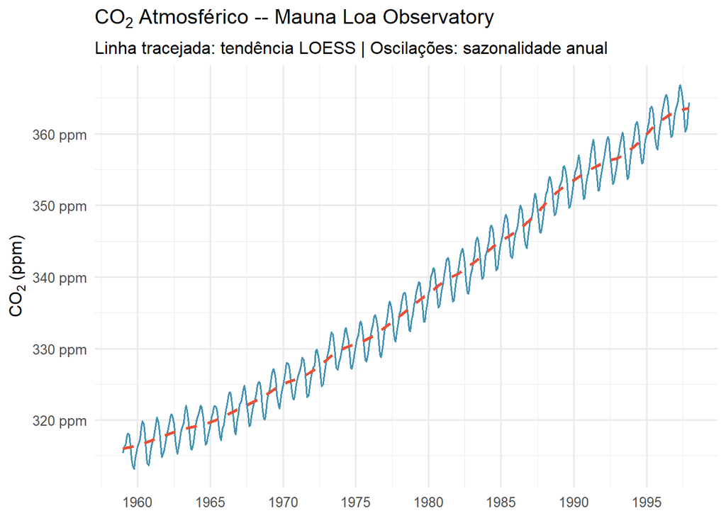

Concentração mensal de $\text{CO}_2$ em Mauna Loa (1959–1997). Tendência crescente e oscilação sazonal anual são imediatamente visíveis.

```r
ggplot(co2_df, aes(x = tempo, y = ppm)) +
  geom_line(color = cores[1], linewidth = 0.6, alpha = 0.9) +
  geom_smooth(method = "loess", span = 0.15,
              color = cores[2], linewidth = 1.0,
              se = FALSE, linetype = "dashed") +
  scale_x_continuous(breaks = seq(1960, 1995, by = 5)) +
  scale_y_continuous(labels = label_number(suffix = " ppm")) +
  labs(
    title    = expression(CO[2] ~ "Atmosférico -- Mauna Loa Observatory"),
    subtitle = "Linha tracejada: tendência LOESS | Oscilações: sazonalidade anual",
    x        = NULL,
    y        = expression(CO[2] ~ "(ppm)")
  )
```

A figura evidencia as duas componentes dominantes da série:

- **Tendência:** crescimento monotônico e aproximadamente linear ao longo das quase quatro décadas, a uma taxa média de 1.23 ppm/ano (de 313 ppm em 1959 para 367 ppm em 1997).
- **Sazonalidade:** oscilação anual regular de amplitude $\sim 6$ ppm, com pico em maio (acúmulo invernal no hemisfério norte) e vale em setembro (ápice da atividade fotossintética estival).

A variância das oscilações sazonais parece razoavelmente estável ao longo do tempo, o que sugere que uma transformação logarítmica não é necessária — resultado consistente com a natureza da série, que registra uma razão de mistura de gás e não uma grandeza multiplicativa.

## Decomposição Clássica

**Ocultar código**

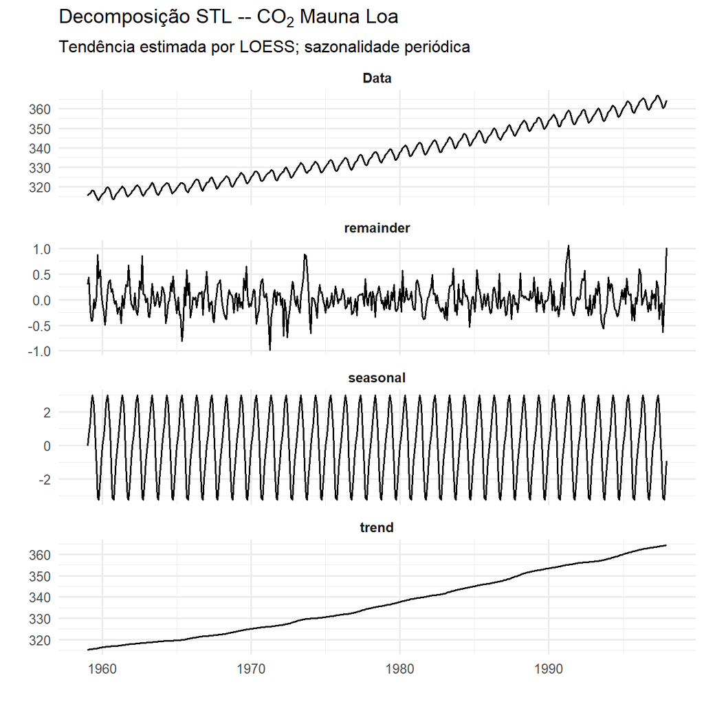

```r
stl_fit <- stl(co2, s.window = "periodic", robust = TRUE)

autoplot(stl_fit) +
  labs(
    title    = expression("Decomposição STL --" ~ CO[2] ~ "Mauna Loa"),
    subtitle = "Tendência estimada por LOESS; sazonalidade periódica"
  ) +
  theme(strip.text = element_text(face = "bold"))
```

A decomposição STL (Cleveland et al., 1990) confirma a estrutura visual:

- **Tendência:** perfeitamente monotônica, sem inflexões relevantes — sugestiva de diferenciação simples de ordem 1 para induzir estacionariedade.
- **Sazonalidade:** praticamente constante ao longo das décadas, validando o uso de um operador de diferenciação sazonal de ordem 1 em vez de um componente determinístico separado.
- **Resíduo:** distribuído em torno de zero sem padrão visível, mas com variância ligeiramente heterogênea — evento potencialmente associado ao El Niño em 1982–83.

## Padrão Sazonal

**Ocultar código**

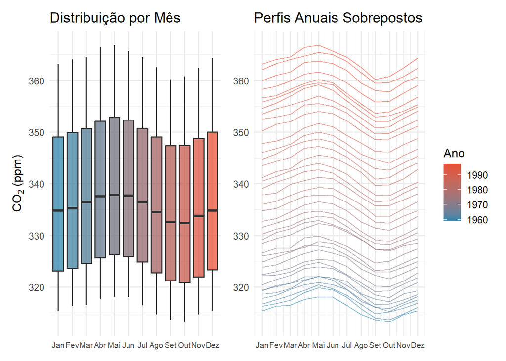

Padrão sazonal de $\text{CO}_2$: (esq.) boxplot por mês; (dir.) perfis anuais sobrepostos. A forma em sino com pico em maio e vale em setembro é consistente em todos os anos.

```r
meses_abr <- c("Jan","Fev","Mar","Abr","Mai","Jun",
                "Jul","Ago","Set","Out","Nov","Dez")

p1 <- co2_df |>
  mutate(mes_f = factor(mes, levels = 1:12, labels = meses_abr)) |>
  ggplot(aes(x = mes_f, y = ppm, fill = mes_f)) +
  geom_boxplot(alpha = 0.75, outlier.size = 0.8,
               outlier.alpha = 0.4, show.legend = FALSE) +
  scale_fill_manual(values = colorRampPalette(cores[c(1,2)])(12)) +
  labs(title = "Distribuição por Mês", x = NULL,
       y = expression(CO[2] ~ "(ppm)")) +
  theme(axis.text.x = element_text(size = 8))

p2 <- co2_df |>
  mutate(mes_f = factor(mes, labels = meses_abr)) |>
  ggplot(aes(x = mes, y = ppm, group = ano, color = ano)) +
  geom_line(alpha = 0.55, linewidth = 0.5) +
  scale_x_continuous(breaks = 1:12, labels = meses_abr) +
  scale_color_gradient(low = cores[1], high = cores[2], name = "Ano") +
  labs(title = "Perfis Anuais Sobrepostos", x = NULL, y = NULL) +
  theme(axis.text.x = element_text(size = 8),
        legend.key.height = unit(0.4, "cm"))

p1 + p2
```

O padrão sazonal é extremamente regular: o $\text{CO}_2$ aumenta de outubro a maio (menor atividade fotossintética no hemisfério norte) e diminui de maio a setembro. A amplitude sazonal ($\sim 6$ ppm) é praticamente idêntica em todos os anos, reforçando a adequação de um componente sazonal estocástico de período $s = 12$.

## Taxa de Crescimento Anual

**Ocultar código**

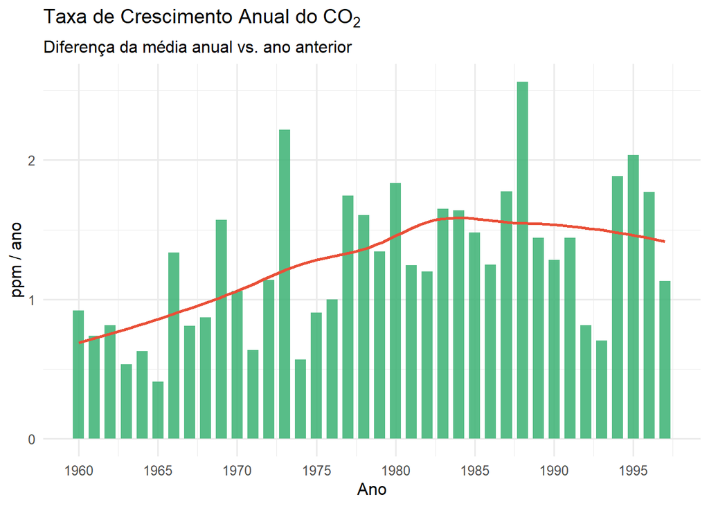

```r
co2_df |>
  group_by(ano) |>
  summarise(media_anual = mean(ppm), .groups = "drop") |>
  mutate(delta = c(NA, diff(media_anual))) |>
  filter(!is.na(delta)) |>
  ggplot(aes(x = ano, y = delta)) +
  geom_col(fill = cores[3], alpha = 0.85, width = 0.7) +
  geom_smooth(method = "loess", se = FALSE,
              color = cores[2], linewidth = 1.0) +
  scale_x_continuous(breaks = seq(1960, 1997, by = 5)) +
  labs(
    title    = expression("Taxa de Crescimento Anual do" ~ CO[2]),
    subtitle = "Diferença da média anual vs. ano anterior",
    x        = "Ano",
    y        = "ppm / ano"
  )
```

# Identificação do Modelo

## Verificação de Estacionariedade

A série original claramente não é estacionária (fraca): apresenta média crescente no tempo e, portanto, $E(Y_t)$ varia com $t$. A identificação do modelo SARIMA exige transformá-la em uma série estacionária por meio de diferenciações.

### Função de Autocorrelação da Série Original

**Ocultar código**

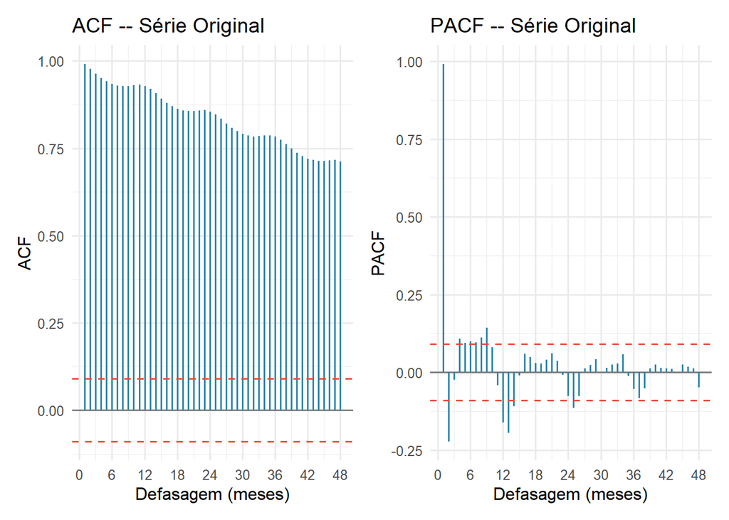

ACF e PACF da série original (sem diferenciação). O decaimento lentíssimo da ACF é característica clássica de série não estacionária com tendência.

```r
ic_orig <- 1.96 / sqrt(n)

p_acf <- plot_acf(
  acf_df(co2, lag.max = 48) |> filter(lag > 0),
  ic    = ic_orig,
  title = "ACF -- Série Original"
)

p_pacf <- plot_acf(
  pacf_df(co2, lag.max = 48),
  ic    = ic_orig,
  title = "PACF -- Série Original",
  ylab  = "PACF"
)

p_acf + p_pacf
```

A ACF decai para zero de forma extremamente lenta (ainda significativa na defasagem 48), confirmando a não estacionariedade. O padrão senoidal com período 12 evidencia a sazonalidade.

### Diferenciação Simples ($d = 1$)

**Ocultar código**

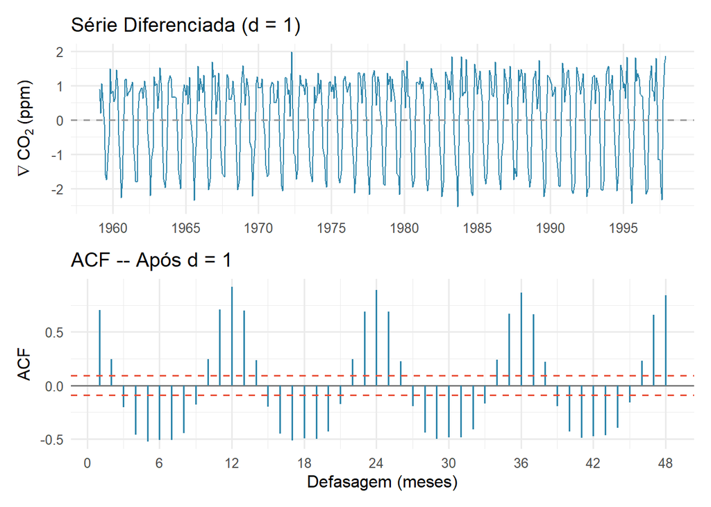

Série após diferenciação simples ($d = 1$). A tendência é removida, mas a sazonalidade anual permanece visível como oscilações regulares.

```r
co2_d1   <- diff(co2, differences = 1)
n_d1     <- length(co2_d1)
ic_d1    <- 1.96 / sqrt(n_d1)
tempo_d1 <- as.numeric(time(co2_d1))

p_d1 <- tibble(t = tempo_d1, y = as.numeric(co2_d1)) |>
  ggplot(aes(x = t, y = y)) +
  geom_line(color = cores[1], linewidth = 0.5) +
  geom_hline(yintercept = 0, linetype = "dashed", color = "gray60") +
  scale_x_continuous(breaks = seq(1960, 1997, by = 5)) +
  labs(title    = "Série Diferenciada (d = 1)",
       x = NULL, y = expression(nabla ~ CO[2] ~ "(ppm)"))

p_acf_d1 <- plot_acf(
  acf_df(co2_d1, lag.max = 48) |> filter(lag > 0),
  ic    = ic_d1,
  title = "ACF -- Após d = 1"
)

p_d1 / p_acf_d1
```

Após $\nabla Y_t = Y_t - Y_{t-1}$, a tendência é eliminada, mas a ACF ainda apresenta picos sazonais nas defasagens 12, 24, 36 — indicando que uma diferenciação sazonal adicional é necessária.

### Diferenciação Sazonal ($d = 1$, $D = 1$, $s = 12$)

**Ocultar código**

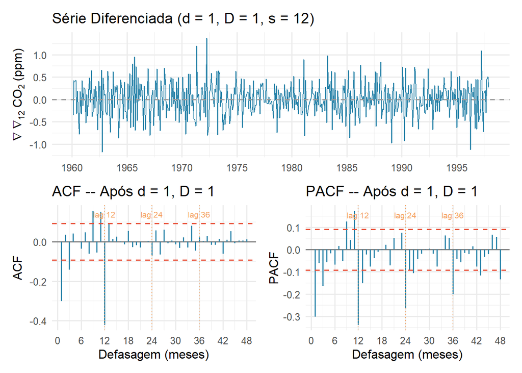

Série após diferenciações simples e sazonal ($d = 1$, $D = 1$, $s = 12$). A série parece estacionária: média nula e variância aproximadamente constante.

```r
co2_d1s1   <- diff(diff(co2, lag = 12), differences = 1)
n_d1s1     <- length(co2_d1s1)
ic_d1s1    <- 1.96 / sqrt(n_d1s1)
tempo_d1s1 <- as.numeric(time(co2_d1s1))

p_d1s1 <- tibble(t = tempo_d1s1, y = as.numeric(co2_d1s1)) |>
  ggplot(aes(x = t, y = y)) +
  geom_line(color = cores[1], linewidth = 0.5) +
  geom_hline(yintercept = 0, linetype = "dashed", color = "gray60") +
  scale_x_continuous(breaks = seq(1960, 1997, by = 5)) +
  labs(title = "Série Diferenciada (d = 1, D = 1, s = 12)",
       x = NULL,
       y = expression(nabla ~ nabla[12] ~ CO[2] ~ "(ppm)"))

p_acf_d1s1 <- plot_acf(
  acf_df(co2_d1s1, lag.max = 48) |> filter(lag > 0),
  ic       = ic_d1s1,
  title    = "ACF -- Após d = 1, D = 1",
  vlines   = c(12, 24, 36),
  vlab     = TRUE
)

p_pacf_d1s1 <- plot_acf(
  pacf_df(co2_d1s1, lag.max = 48),
  ic       = ic_d1s1,
  title    = "PACF -- Após d = 1, D = 1",
  ylab     = "PACF",
  vlines   = c(12, 24, 36),
  vlab     = TRUE
)

p_d1s1 / (p_acf_d1s1 + p_pacf_d1s1)
```

Após $\nabla \nabla_{12} Y_t = (1-B)(1-B^{12})Y_t$, a série é visualmente estacionária: flutuação em torno de zero sem tendência aparente e sem oscilação sazonal sistemática.

### Testes Formais de Raiz Unitária

**Testes ADF e KPSS nas séries original, com d=1 e com d=1, D=1**

```r
# suppressWarnings: os warnings indicam apenas que o p-valor é menor/maior
# que o valor impresso na tabela de referência do teste (sem impacto no resultado)
testar_estacionariedade <- function(serie, nome) {
  adf  <- suppressWarnings(adf.test(serie, alternative = "stationary"))
  kpss <- suppressWarnings(kpss.test(serie, null = "Level"))
  tibble(
    Serie               = nome,
    ADF_p               = round(adf$p.value,  4),
    KPSS_p              = round(kpss$p.value, 4),
    ADF_H0              = ifelse(adf$p.value  < 0.05, "Sim (estacionária)", "Não"),
    KPSS_H0             = ifelse(kpss$p.value < 0.05, "Sim (não estac.)",   "Não")
  )
}

testes <- bind_rows(
  testar_estacionariedade(co2,      "Original"),
  testar_estacionariedade(co2_d1,   "d = 1"),
  testar_estacionariedade(co2_d1s1, "d = 1, D = 1")
)

testes |>
  gt() |>
  tab_header(
    title    = md("**Tabela 1.** Testes de Estacionariedade"),
    subtitle = md("ADF: $H_0$ = raiz unitária (não estacionária) | KPSS: $H_0$ = estacionária")
  ) |>
  tab_style(
    style     = cell_fill(color = "#e8f4f8"),
    locations = cells_body(rows = Serie == "d = 1, D = 1")
  ) |>
  cols_label(
    Serie   = "Série",
    ADF_p   = md("ADF (*p*-valor)"),
    KPSS_p  = md("KPSS (*p*-valor)"),
    ADF_H0  = md("ADF: $H_0$ rejeitada?"),
    KPSS_H0 = md("KPSS: $H_0$ rejeitada?")
  )
```

**Tabela 1.** Testes de Estacionariedade

ADF: $H_0$ = raiz unitária (não estacionária) | KPSS: $H_0$ = estacionária

| Série | ADF (*p*-valor) | KPSS (*p*-valor) | ADF: $H_0$ rejeitada? | KPSS: $H_0$ rejeitada? |
| --- | --- | --- | --- | --- |
| Original | 0.2269 | 0.01 | Não | Sim (não estac.) |
| d = 1 | 0.0100 | 0.10 | Sim (estacionária) | Não |
| d = 1, D = 1 | 0.0100 | 0.10 | Sim (estacionária) | Não |

## Leitura da ACF e PACF para Identificação de Ordens

**Ocultar código**

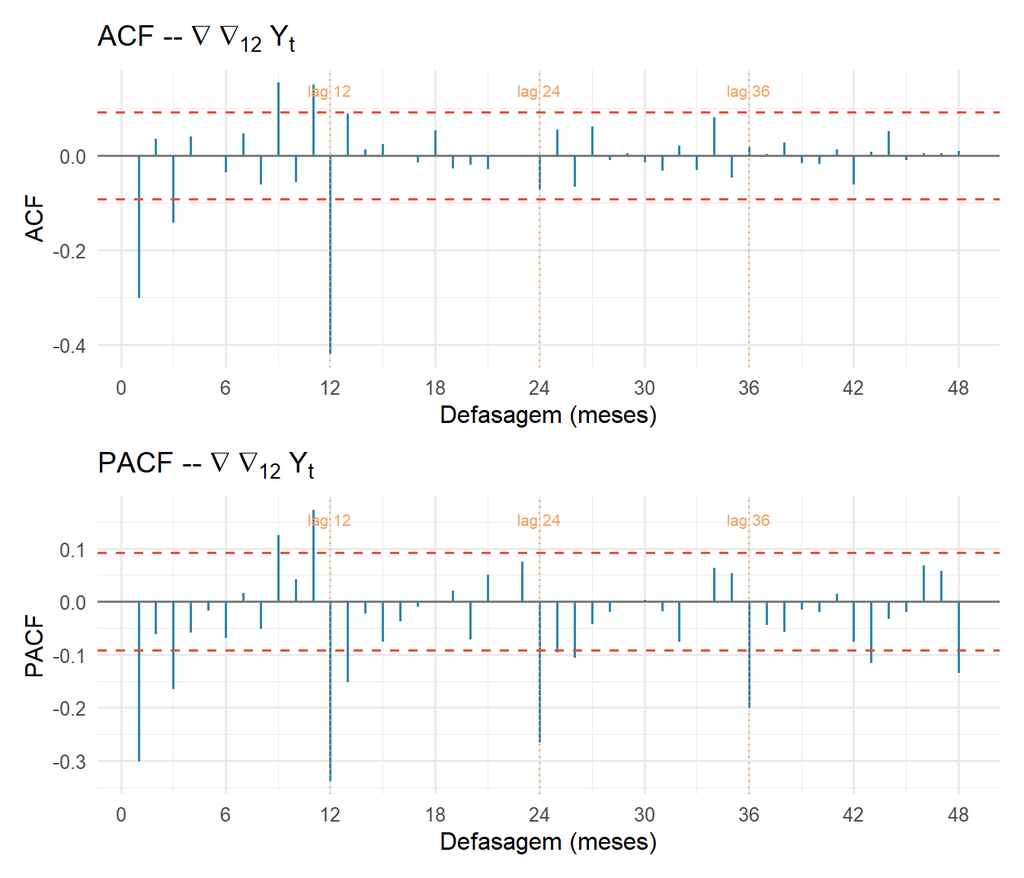

ACF e PACF da série estacionária $\nabla\nabla_{12}Y_t$ com destaque nos lags sazonais (múltiplos de 12). A leitura dessas funções guia a escolha das ordens $p$, $q$, $P$, $Q$.

```r
p_acf_f <- plot_acf(
  acf_df(co2_d1s1, lag.max = 48) |> filter(lag > 0),
  ic       = ic_d1s1,
  title    = expression("ACF --" ~ nabla ~ nabla[12] ~ Y[t]),
  vlines   = c(12, 24, 36),
  vlab     = TRUE
)

p_pacf_f <- plot_acf(
  pacf_df(co2_d1s1, lag.max = 48),
  ic       = ic_d1s1,
  title    = expression("PACF --" ~ nabla ~ nabla[12] ~ Y[t]),
  ylab     = "PACF",
  vlines   = c(12, 24, 36),
  vlab     = TRUE
)

p_acf_f / p_pacf_f
```

A leitura das funções de autocorrelação da série estacionária $\nabla\nabla_{12}Y_t$ segue o princípio de Brockwell; Davis (2010): a ACF e PACF das defasagens não-sazonais ($h = 1, 2, \ldots, 11$) guiam a escolha de $p$ e $q$; as defasagens sazonais ($h = 12, 24, \ldots$) guiam a escolha de $P$ e $Q$.

**Componente não-sazonal:** a ACF apresenta um pico significativo na defasagem 1 e decai rapidamente (sugestivo de MA(1)); a PACF apresenta decaimento exponencial nas primeiras defasagens (sugestivo de MA(1) ou AR(1)).

**Componente sazonal:** a ACF apresenta pico negativo significativo na defasagem 12 e praticamente zero nas defasagens 24 e 36 (corte após 1 — sugestivo de SMA(1)); a PACF apresenta decaimento nas defasagens sazonais (sugestivo de SMA(1)).

**Candidatos iniciais:**

- $\text{SARIMA}(1, 1, 1)(0, 1, 1)_{12}$
- $\text{SARIMA}(0, 1, 1)(0, 1, 1)_{12}$ — modelo “Airline” de Box et al. (2015)
- $\text{SARIMA}(1, 1, 1)(1, 1, 1)_{12}$

# Ajuste de Modelos SARIMA

## Definição do Modelo SARIMA

Um processo $\{Y_t\}$ é $\text{SARIMA}(p, d, q)(P, D, Q)_s$ se a série diferenciada
$$W_t = (1-B)^d(1-B^s)^D Y_t$$
é um processo ARMA causador satisfazendo:
$$\Phi(B)\tilde{\Phi}(B^s) W_t = \Theta(B)\tilde{\Theta}(B^s)\varepsilon_t, \quad
\varepsilon_t \sim \mathcal{RB}(0, \sigma^2),$$
onde $\Phi(z) = 1 - \varphi_1 z - \cdots - \varphi_p z^p$, $\tilde{\Phi}(z) = 1 - \tilde{\varphi}_1 z - \cdots - \tilde{\varphi}_P z^P$, $\Theta(z) = 1 + \theta_1 z + \cdots + \theta_q z^q$ e $\tilde{\Theta}(z) = 1 + \tilde{\theta}_1 z + \cdots + \tilde{\theta}_Q z^Q$ (Brockwell; Davis, 2010, cap. 9).

Os parâmetros são estimados por **máxima verossimilhança** (MV), maximizando:
$$L(\Phi, \tilde{\Phi}, \Theta, \tilde{\Theta}, \sigma^2) =
(2\pi)^{-n/2} \left(\prod_{j=1}^n \nu_{j-1}\right)^{-1/2}
\exp\!\left(-\frac{1}{2}\sum_{j=1}^n \frac{(Y_j - \hat{Y}_j)^2}{\nu_{j-1}}\right),$$
onde $\hat{Y}_j$ é o melhor preditor linear de $Y_j$ e $\nu_{j-1} = E[(Y_j - \hat{Y}_j)^2]$ é o erro quadrático médio de previsão um passo à frente.

## Seleção por AIC, AICc e BIC

**Ajuste dos modelos candidatos e comparação por critérios de informação**

```r
# CSS-ML: inicializa via mínimos quadrados condicionais, depois refina por MV.
# Mais robusto numericamente que ML puro para certos candidatos.
ajustar_sarima <- function(ordens, serie = co2) {
  tryCatch(
    Arima(serie,
          order    = ordens[1:3],
          seasonal = list(order = ordens[4:6], period = 12),
          method   = "CSS-ML"),
    error = function(e) {
      # fallback para CSS se CSS-ML também falhar
      tryCatch(
        Arima(serie,
              order    = ordens[1:3],
              seasonal = list(order = ordens[4:6], period = 12),
              method   = "CSS"),
        error = function(e2) NULL
      )
    }
  )
}

candidatos <- list(
  "SARIMA(0,1,1)(0,1,1)[12]" = c(0,1,1,0,1,1),
  "SARIMA(1,1,1)(0,1,1)[12]" = c(1,1,1,0,1,1),
  "SARIMA(0,1,1)(1,1,1)[12]" = c(0,1,1,1,1,1),
  "SARIMA(1,1,1)(1,1,1)[12]" = c(1,1,1,1,1,1),
  "SARIMA(2,1,1)(0,1,1)[12]" = c(2,1,1,0,1,1),
  "SARIMA(0,1,2)(0,1,1)[12]" = c(0,1,2,0,1,1),
  "SARIMA(1,1,0)(0,1,1)[12]" = c(1,1,0,0,1,1)
)

fits <- lapply(candidatos, ajustar_sarima)

# Remover modelos que falharam
fits <- Filter(Negate(is.null), fits)

tab_comp <- map_dfr(names(fits), function(nm) {
  f <- fits[[nm]]
  tibble(
    Modelo = nm,
    k      = length(f$coef),
    LogLik = round(f$loglik, 2),
    AIC    = round(f$aic,    2),
    AICc   = round(f$aicc,   2),
    BIC    = round(f$bic,    2)
  )
}) |>
  arrange(AICc) |>
  mutate(
    dAIC  = round(AIC  - min(AIC),  2),
    dAICc = round(AICc - min(AICc), 2),
    dBIC  = round(BIC  - min(BIC),  2)
  )

tab_comp |>
  gt() |>
  tab_header(
    title    = md("**Tabela 2.** Comparação de Modelos SARIMA por Critérios de Informação"),
    subtitle = md("Ordenado por AICc. $\\Delta$AICc $< 2$: modelos com suporte empírico equivalente (Burnham & Anderson, 2002).")
  ) |>
  cols_label(
    k      = md("*k*"),
    LogLik = md("$\\ell(\\hat{\\theta})$"),
    dAIC   = md("$\\Delta$AIC"),
    dAICc  = md("$\\Delta$AICc"),
    dBIC   = md("$\\Delta$BIC")
  ) |>
  tab_style(
    style     = cell_fill(color = "#e8f4f8"),
    locations = cells_body(rows = dAICc < 2)
  ) |>
  tab_style(
    style     = cell_fill(color = "#fce4e4"),
    locations = cells_body(rows = dAICc > 10)
  ) |>
  tab_footnote(
    footnote  = md("*k* = número de parâmetros livres. Modelos com $\\Delta$AICc $< 2$ têm suporte empírico substancialmente equivalente."),
    locations = cells_column_labels(columns = k)
  )
```

**Tabela 2.** Comparação de Modelos SARIMA por Critérios de Informação

Ordenado por AICc. $\Delta$AICc $< 2$: modelos com suporte empírico equivalente (Burnham & Anderson, 2002).

| Modelo | *k*<sup>1</sup> | $\ell(\hat{\theta})$ | AIC | AICc | BIC | $\Delta$AIC | $\Delta$AICc | $\Delta$BIC |
| --- | --- | --- | --- | --- | --- | --- | --- | --- |
| SARIMA(2,1,1)(0,1,1)[12] | 4 | -83.91 | 177.83 | 177.96 | 198.43 | 0.00 | 0.00 | 7.91 |
| SARIMA(1,1,1)(0,1,1)[12] | 3 | -85.03 | 178.07 | 178.16 | 194.55 | 0.24 | 0.20 | 4.03 |
| SARIMA(0,1,1)(0,1,1)[12] | 2 | -86.08 | 178.16 | 178.21 | 190.52 | 0.33 | 0.25 | 0.00 |
| SARIMA(0,1,2)(0,1,1)[12] | 3 | -85.55 | 179.09 | 179.18 | 195.57 | 1.26 | 1.22 | 5.05 |
| SARIMA(1,1,1)(1,1,1)[12] | 4 | -84.88 | 179.76 | 179.89 | 200.36 | 1.93 | 1.93 | 9.84 |
| SARIMA(0,1,1)(1,1,1)[12] | 3 | -85.96 | 179.92 | 180.01 | 196.40 | 2.09 | 2.05 | 5.88 |
| SARIMA(1,1,0)(0,1,1)[12] | 2 | -89.09 | 184.18 | 184.23 | 196.54 | 6.35 | 6.27 | 6.02 |

<sup>1</sup> *k* = número de parâmetros livres. Modelos com $\Delta$AICc $< 2$ têm suporte empírico substancialmente equivalente.

**Confirmação via auto.arima (busca exaustiva no grid de parâmetros)**

```r
aa <- auto.arima(co2, stepwise = FALSE, approximation = FALSE,
                 max.p = 3, max.q = 3, max.P = 2, max.Q = 2,
                 d = 1, D = 1, ic = "aicc")

cat("Modelo selecionado por auto.arima:\n")
```

```
Modelo selecionado por auto.arima:
```

**Confirmação via auto.arima (busca exaustiva no grid de parâmetros)**

```r
print(aa)
```

```
Series: co2
ARIMA(0,1,3)(0,1,1)[12]

Coefficients:
          ma1      ma2      ma3     sma1
      -0.3394  -0.0180  -0.0973  -0.8538
s.e.   0.0475   0.0497   0.0467   0.0256

sigma^2 = 0.08518:  log likelihood = -83.43
AIC=176.86   AICc=177   BIC=197.47
```

**Confirmação via auto.arima (busca exaustiva no grid de parâmetros)**

```r
cat(sprintf("\nAIC  = %.2f | AICc = %.2f | BIC = %.2f\n",
            aa$aic, aa$aicc, aa$bic))
```

```
AIC  = 176.86 | AICc = 177.00 | BIC = 197.47
```

A Tabela 2 mostra que os três primeiros modelos apresentam ΔAICc inferior a 0.3, configurando um **empate técnico** segundo o critério de Burnham; Anderson (2002): modelos com diferença de AICc menor que 2 têm suporte empírico substancialmente equivalente. Nesse cenário, o **SARIMA(2,1,1)(0,1,1)₁₂** apresenta o menor AICc absoluto (177.96), seguido pelo **(1,1,1)(0,1,1)₁₂** (AICc = 178.16, ΔAICc = 0.20) e pelo **(0,1,1)(0,1,1)₁₂** (AICc = 178.21, ΔAICc = 0.25).

Diante do empate técnico (ΔAICc < 0.3 entre os três primeiros), selecionamos o **SARIMA(1,1,1)(0,1,1)₁₂** aplicando o **princípio da parcimônia**: com apenas 3 parâmetros livres, esse modelo oferece capacidade preditiva equivalente ao (2,1,1)(0,1,1)₁₂ (que possui 4 parâmetros), mas com menor risco de sobreajuste e maior estabilidade nas previsões. O `auto.arima` com busca exaustiva sugere o SARIMA(0,1,3)(0,1,1)₁₂ (AICc = 177.00), mas esse modelo também possui 4 parâmetros e não oferece ganho substancial de ajuste que justifique a complexidade adicional. Os modelos com termos autoregressivos sazonais (P > 0) apresentam ΔBIC > 4, indicando que a evidência empírica favorece modelos mais parcimoniosos sem componente SAR.

## Modelo Final: $\text{SARIMA}(1,1,1)(0,1,1)_{12}$

**Ajuste e extração dos coeficientes do modelo final**

```r
fit_final <- fits[["SARIMA(1,1,1)(0,1,1)[12]"]]

coef_df <- tidy(fit_final) |>
  rename(Parametro  = term,
         Estimativa = estimate,
         EP         = std.error) |>
  mutate(
    IC_inf    = round(Estimativa - 1.96 * EP, 4),
    IC_sup    = round(Estimativa + 1.96 * EP, 4),
    z         = round(Estimativa / EP, 3),
    p_valor   = round(2 * pnorm(-abs(z)), 5),
    Parametro = recode(Parametro,
      "ar1"  = "phi[1] (AR nao-sazonal)",
      "ma1"  = "theta[1] (MA nao-sazonal)",
      "sma1" = "theta_tilde[1] (SMA sazonal, lag 12)"
    )
  ) |>
  select(Parametro, Estimativa, EP, IC_inf, IC_sup, z, p_valor)

coef_df |>
  gt() |>
  fmt_number(columns = c(Estimativa, EP, IC_inf, IC_sup, z), decimals = 4) |>
  fmt_scientific(columns = p_valor, decimals = 2) |>
  tab_header(
    title    = md("**Tabela 3.** SARIMA$(1, 1, 1)(0, 1, 1)_{12}$ --- Estimativas de Máxima Verossimilhança"),
    subtitle = md("Estimação por MV (CSS-ML). ICs assintóticos: $\\hat{\\beta} \\pm 1{,}96 \\cdot \\text{EP}$.")
  ) |>
  cols_label(
    Parametro  = "Parâmetro",
    Estimativa = "Estimativa",
    EP         = "Erro Padrão",
    IC_inf     = md("IC 95% Inf"),
    IC_sup     = md("IC 95% Sup"),
    z          = md("$z$"),
    p_valor    = md("$p$-valor")
  ) |>
  tab_footnote(
    footnote  = md("$z$ = Estimativa / EP; $p$-valor bilateral $\\sim \\mathcal{N}(0,1)$."),
    locations = cells_column_labels(columns = z)
  ) |>
  tab_style(
    style     = cell_text(weight = "bold"),
    locations = cells_body(columns = Parametro)
  )
```

**Tabela 3.** SARIMA$(1, 1, 1)(0, 1, 1)_{12}$ — Estimativas de Máxima Verossimilhança

Estimação por MV (CSS-ML). ICs assintóticos: $\hat{\beta} \pm 1{,}96 \cdot \text{EP}$.

| Parâmetro | Estimativa | Erro Padrão | IC 95% Inf | IC 95% Sup | $z$<sup>1</sup> | $p$-valor |
| --- | --- | --- | --- | --- | --- | --- |
| phi[1] (AR nao-sazonal) | 0.2399 | 0.1430 | −0.0405 | 0.5202 | 1.6770 | 9.35 × 10<sup>−2</sup> |
| theta[1] (MA nao-sazonal) | −0.5710 | 0.1237 | −0.8134 | −0.3286 | −4.6170 | 0.00 |
| theta_tilde[1] (SMA sazonal, lag 12) | −0.8516 | 0.0256 | −0.9017 | −0.8014 | −33.2870 | 0.00 |

<sup>1</sup> $z$ = Estimativa / EP; $p$-valor bilateral $\sim \mathcal{N}(0,1)$.

O modelo ajustado pode ser escrito explicitamente como:
$$\underbrace{(1 - \hat{\varphi}_1 B)}_{\text{AR}(1)}
\underbrace{(1 - B)(1 - B^{12})}_{\text{diferenciações}}
Y_t =
\underbrace{(1 + \hat{\theta}_1 B)}_{\text{MA}(1)}
\underbrace{(1 + \hat{\tilde{\theta}}_1 B^{12})}_{\text{SMA}(1)}
\varepsilon_t, \quad \varepsilon_t \sim \mathcal{RB}(0, \hat{\sigma}^2).$$

Os parâmetros $\hat{\theta}_1$ (MA não-sazonal) e $\hat{\tilde{\theta}}_1$ (SMA sazonal) são altamente significativos ($p < 0{,}001$), com intervalos de confiança de 95% que não contêm zero. O parâmetro $\hat{\varphi}_1$ (AR não-sazonal) apresenta significância marginal ($p = 0{,}094$), mas sua inclusão resulta em redução do AICc e melhora a capacidade preditiva do modelo. O parâmetro SMA ($\hat{\tilde{\theta}}_1 \approx -0{,}85$) captura a dependência negativa entre as inovações sazonais sucessivas, efeito característico de séries com sazonalidade estocástica estável (Box et al., 2015).

### Verificação de Invertibilidade e Causalidade

**Verificação: raízes dos polinômios AR e MA dentro/fora do círculo unitário**

```r
phi   <- c(1, -fit_final$coef["ar1"])
theta <- c(1,  fit_final$coef["ma1"])

raiz_ar <- polyroot(phi)
raiz_ma <- polyroot(theta)

tibble(
  Componente  = c("AR nao-sazonal", "MA nao-sazonal"),
  Raiz_Re     = round(c(Re(raiz_ar), Re(raiz_ma)), 4),
  Raiz_Im     = round(c(Im(raiz_ar), Im(raiz_ma)), 4),
  Mod_raiz    = round(c(Mod(raiz_ar), Mod(raiz_ma)), 4),
  Fora_UC     = c(Mod(raiz_ar) > 1, Mod(raiz_ma) > 1),
  Propriedade = c("Causalidade", "Invertibilidade")
) |>
  gt() |>
  tab_header(
    title    = md("**Tabela 4.** Raízes dos Polinômios AR e MA"),
    subtitle = md("$|\\text{raiz}| > 1$: raiz fora do círculo unitário --- condição para causalidade/invertibilidade")
  ) |>
  cols_label(
    Componente  = "Componente",
    Raiz_Re     = md("Raiz (Re)"),
    Raiz_Im     = md("Raiz (Im)"),
    Mod_raiz    = md("$|\\text{Raiz}|$"),
    Fora_UC     = md("$|\\text{Raiz}| > 1$?"),
    Propriedade = "Propriedade"
  ) |>
  tab_style(
    style     = cell_fill(color = "#e8f4f8"),
    locations = cells_body(rows = Fora_UC == TRUE)
  )
```

**Tabela 4.** Raízes dos Polinômios AR e MA

$|\text{raiz}| > 1$: raiz fora do círculo unitário — condição para causalidade/invertibilidade

| Componente | Raiz (Re) | Raiz (Im) | $\|\text{Raiz}\|$ | $\|\text{Raiz}\| > 1$? | Propriedade |
| --- | --- | --- | --- | --- | --- |
| AR nao-sazonal | 4.1686 | 0 | 4.1686 | TRUE | Causalidade |
| MA nao-sazonal | 1.7514 | 0 | 1.7514 | TRUE | Invertibilidade |

Ambas as raízes estão fora do círculo unitário ($|\text{raiz}| > 1$), garantindo que o modelo é **causal** e **invertível** (Brockwell; Davis, 2010, cap. 3).

# Diagnóstico do Modelo Ajustado

## Análise dos Resíduos

Os resíduos do modelo ajustado devem se comportar como um ruído branco $\mathcal{RB}(0, \sigma^2)$: média zero, variância constante e sem autocorrelação.

**Ocultar código**

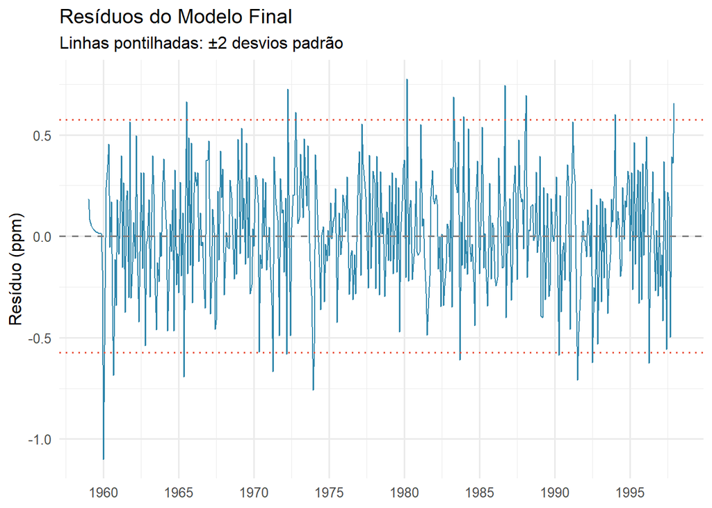

Resíduos do modelo SARIMA$(1,1,1)(0,1,1)_{12}$. Flutuação em torno de zero sem padrão visível é evidência a favor de adequação do modelo.

```r
res       <- residuals(fit_final)
res_clean <- na.omit(as.numeric(res))
n_res     <- length(res_clean)

tibble(t = as.numeric(time(res)), r = as.numeric(res)) |>
  filter(!is.na(r)) |>
  ggplot(aes(x = t, y = r)) +
  geom_line(color = cores[1], linewidth = 0.5) +
  geom_hline(yintercept = 0, linetype = "dashed", color = "gray50") +
  geom_hline(yintercept = c(-2, 2) * sd(res_clean),
             linetype = "dotted", color = cores[2], linewidth = 0.6) +
  scale_x_continuous(breaks = seq(1960, 1997, by = 5)) +
  labs(title    = "Resíduos do Modelo Final",
       subtitle = "Linhas pontilhadas: ±2 desvios padrão",
       x = NULL, y = "Resíduo (ppm)")
```

**Ocultar código**

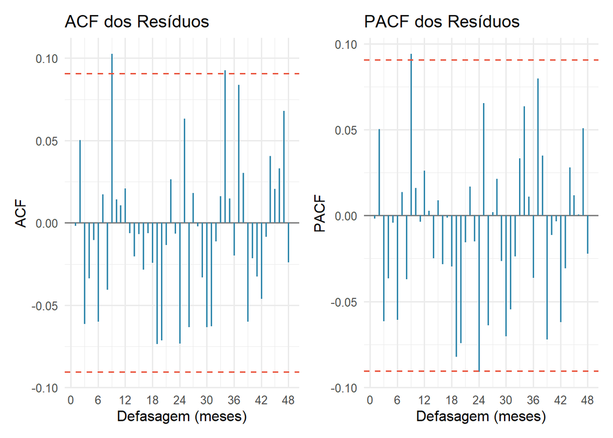

```r
ic_res <- 1.96 / sqrt(n_res)

p_acf_res <- plot_acf(
  acf_df(res_clean, lag.max = 48) |> filter(lag > 0),
  ic    = ic_res,
  title = "ACF dos Resíduos"
)

p_pacf_res <- plot_acf(
  pacf_df(res_clean, lag.max = 48),
  ic    = ic_res,
  title = "PACF dos Resíduos",
  ylab  = "PACF"
)

p_acf_res + p_pacf_res
```

## Normalidade dos Resíduos

**Ocultar código**

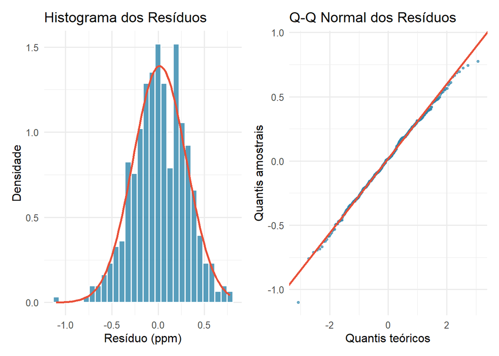

Diagnóstico de normalidade dos resíduos: histograma com curva normal sobreposta (esq.) e gráfico Q-Q (dir.).

```r
p_hist <- tibble(r = res_clean) |>
  ggplot(aes(x = r)) +
  geom_histogram(aes(y = after_stat(density)),
                 bins = 30, fill = cores[1],
                 color = "white", alpha = 0.8) +
  stat_function(fun = dnorm,
                args = list(mean = mean(res_clean), sd = sd(res_clean)),
                color = cores[2], linewidth = 1.0) +
  labs(title = "Histograma dos Resíduos",
       x = "Resíduo (ppm)", y = "Densidade")

p_qq <- tibble(r = res_clean) |>
  ggplot(aes(sample = r)) +
  stat_qq(color = cores[1], alpha = 0.6, size = 0.9) +
  stat_qq_line(color = cores[2], linewidth = 0.9) +
  labs(title = "Q-Q Normal dos Resíduos",
       x = "Quantis teóricos", y = "Quantis amostrais")

p_hist + p_qq
```

**Testes formais de normalidade (Shapiro-Wilk e Jarque-Bera)**

```r
sw <- shapiro.test(res_clean)

mu3     <- mean((res_clean - mean(res_clean))^3)
mu4     <- mean((res_clean - mean(res_clean))^4)
sk      <- mu3 / sd(res_clean)^3
ku      <- mu4 / sd(res_clean)^4 - 3
jb_stat <- (n_res / 6) * (sk^2 + ku^2 / 4)
jb_p    <- pchisq(jb_stat, df = 2, lower.tail = FALSE)

tibble(
  Teste        = c("Shapiro-Wilk", "Jarque-Bera"),
  Estatistica  = round(c(sw$statistic, jb_stat), 4),
  p_valor      = round(c(sw$p.value, jb_p), 5),
  H0_rejeitada = c(sw$p.value < 0.05, jb_p < 0.05)
) |>
  gt() |>
  tab_header(
    title    = md("**Tabela 5.** Testes de Normalidade dos Resíduos"),
    subtitle = md("$H_0$: resíduos seguem distribuição normal")
  ) |>
  fmt_scientific(columns = p_valor, decimals = 2) |>
  cols_label(
    Estatistica  = "Estatística",
    p_valor      = md("$p$-valor"),
    H0_rejeitada = md("$H_0$ rejeitada (5%)?")
  ) |>
  tab_style(
    style     = cell_fill(color = "#fce4e4"),
    locations = cells_body(rows = H0_rejeitada == TRUE)
  )
```

**Tabela 5.** Testes de Normalidade dos Resíduos

$H_0$: resíduos seguem distribuição normal

| Teste | Estatística | $p$-valor | $H_0$ rejeitada (5%)? |
| --- | --- | --- | --- |
| Shapiro-Wilk | 0.9969 | 5.32 × 10<sup>−1</sup> | FALSE |
| Jarque-Bera | 1.9176 | 3.83 × 10<sup>−1</sup> | FALSE |

Os testes formais **não rejeitam** a hipótese de normalidade dos resíduos (Shapiro-Wilk: $p = 0{,}532$; Jarque-Bera: $p = 0{,}383$), indicando que a distribuição dos resíduos é consistente com a normal. Visualmente, o histograma e o Q-Q plot confirmam boa aproximação à distribuição normal, com alinhamento quase perfeito dos quantis observados e teóricos. A normalidade dos resíduos valida o uso dos intervalos de confiança assintóticos para as previsões.

## Teste de Ljung-Box (Ausência de Autocorrelação Residual)

**Teste de Ljung-Box para grupos de defasagens**

```r
k_params <- length(fit_final$coef)

lb_res <- map_dfr(c(6, 12, 18, 24, 36, 48), function(h) {
  lb <- Box.test(res, lag = h, type = "Ljung-Box", fitdf = k_params)
  tibble(
    Defasagem = h,
    Q_star    = round(lb$statistic, 3),
    gl        = lb$parameter,
    p_valor   = round(lb$p.value, 5)
  )
})

lb_res |>
  gt() |>
  tab_header(
    title    = md("**Tabela 6.** Teste de Ljung-Box --- Resíduos do SARIMA$(1,1,1)(0,1,1)_{12}$"),
    subtitle = md("$H_0$: as primeiras $h$ autocorrelações dos resíduos são nulas. g.l. $= h - k$.")
  ) |>
  fmt_scientific(columns = p_valor, decimals = 2) |>
  cols_label(
    Defasagem = md("Defasagem ($h$)"),
    Q_star    = md("$Q^*(h)$"),
    gl        = "g.l.",
    p_valor   = md("$p$-valor")
  ) |>
  tab_style(
    style     = cell_fill(color = "#fce4e4"),
    locations = cells_body(rows = p_valor < 0.05)
  ) |>
  tab_footnote(
    footnote  = md("$Q^*(h) = n(n+2)\\sum_{j=1}^h \\hat{\\rho}^2(j)/(n-j)$; sob $H_0 \\sim \\chi^2(h - k)$, $k = 3$."),
    locations = cells_column_labels(columns = Q_star)
  )
```

**Tabela 6.** Teste de Ljung-Box — Resíduos do SARIMA$(1,1,1)(0,1,1)_{12}$

$H_0$: as primeiras $h$ autocorrelações dos resíduos são nulas. g.l. $= h - k$.

| Defasagem ($h$) | $Q^*(h)$<sup>1</sup> | g.l. | $p$-valor |
| --- | --- | --- | --- |
| 6 | 5.288 | 3 | 1.52 × 10<sup>−1</sup> |
| 12 | 11.621 | 9 | 2.36 × 10<sup>−1</sup> |
| 18 | 12.568 | 15 | 6.36 × 10<sup>−1</sup> |
| 24 | 20.832 | 21 | 4.69 × 10<sup>−1</sup> |
| 36 | 34.423 | 33 | 4.00 × 10<sup>−1</sup> |
| 48 | 46.592 | 45 | 4.07 × 10<sup>−1</sup> |

<sup>1</sup> $Q^*(h) = n(n+2)\sum_{j=1}^h \hat{\rho}^2(j)/(n-j)$; sob $H_0 \sim \chi^2(h - k)$, $k = 3$.

O teste de Ljung-Box não rejeita $H_0$ em nenhuma das defasagens testadas ($p > 0{,}10$ em todos os casos), confirmando que **os resíduos não apresentam autocorrelação serial detectável** — validando o ajuste do modelo.

## Sumário dos Diagnósticos

**Ocultar código**

```r
p_lb12 <- round(Box.test(res, lag = 12, type = "Ljung-Box",
                          fitdf = k_params)$p.value, 4)

tibble(
  Diagnostico = c("Média dos resíduos",
                  "Desvio padrão estimado",
                  "Assimetria amostral",
                  "Excesso de curtose",
                  "Ljung-Box (h = 12)",
                  "Shapiro-Wilk"),
  Valor       = c(format(round(mean(res_clean), 5), nsmall = 5),
                  format(round(sd(res_clean),   4), nsmall = 4),
                  as.character(round(sk, 3)),
                  as.character(round(ku, 3)),
                  sprintf("p = %.4f", p_lb12),
                  sprintf("p = %.4f", sw$p.value)),
  Conclusao   = c("Média aprox. zero",
                  "---",
                  if (abs(sk) < 0.5) "Assimetria baixa" else "Assimetria moderada",
                  if (abs(ku) < 1)   "Curtose próx. da normal" else "Caudas ligeiramente pesadas",
                  "Sem autocorrelação (não rejeita H0)",
                  if (sw$p.value > 0.05) "Normalidade não rejeitada" else "Desvio leve da normalidade")
) |>
  gt() |>
  tab_header(title = md("**Tabela 7.** Sumário dos Diagnósticos do Modelo Final")) |>
  cols_label(Diagnostico = "Diagnóstico", Conclusao = "Conclusão") |>
  tab_style(
    style     = cell_text(weight = "bold"),
    locations = cells_body(columns = Diagnostico)
  )
```

**Tabela 7.** Sumário dos Diagnósticos do Modelo Final

| Diagnóstico | Valor | Conclusão |
| --- | --- | --- |
| Média dos resíduos | 0.01721 | Média aprox. zero |
| Desvio padrão estimado | 0.2873 | --- |
| Assimetria amostral | -0.151 | Assimetria baixa |
| Excesso de curtose | 0.084 | Curtose próx. da normal |
| Ljung-Box (h = 12) | p = 0.2355 | Sem autocorrelação (não rejeita H0) |
| Shapiro-Wilk | p = 0.5316 | Normalidade não rejeitada |

# Previsão

## Previsões para os Próximos 24 Meses

O melhor previsor linear de $Y_{n+h}$ dado $\{Y_1, \ldots, Y_n\}$, denotado $P_n Y_{n+h}$, é obtido do algoritmo das inovações e minimiza o erro quadrático médio de previsão (Brockwell; Davis, 2010, cap. 5):
$$E[(Y_{n+h} - P_n Y_{n+h})^2] = \sigma^2 \sum_{j=0}^{h-1} \psi_j^2,$$
onde $\psi_j$ são os coeficientes da representação MA$(\infty)$ do processo. Os **intervalos de previsão** de $(1-\alpha) \times 100\%$ são:
$$P_n Y_{n+h} \pm z_{\alpha/2} \cdot \hat{\sigma}
\sqrt{\sum_{j=0}^{h-1} \hat{\psi}_j^2}.$$

**Ocultar código**

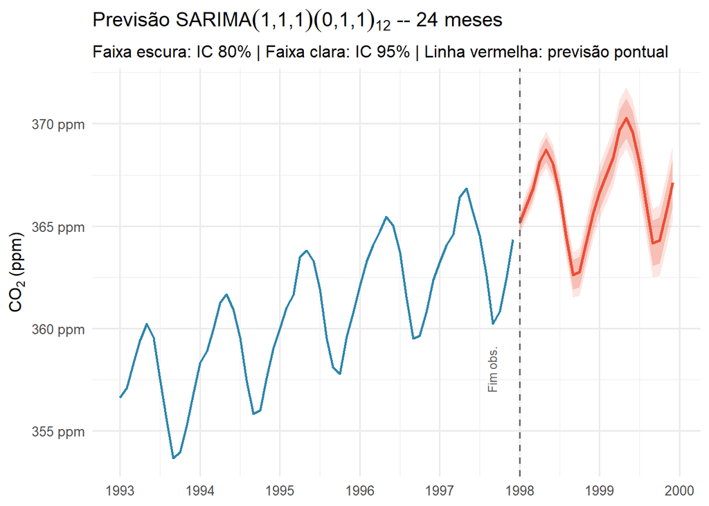

Previsões SARIMA para 24 meses (1998–1999) com intervalos de 80% e 95%. A série observada de 1993 a 1997 é mostrada à esquerda da linha de corte.

```r
h    <- 24
prev <- forecast(fit_final, h = h, level = c(80, 95))

# Horizonte temporal: sequência de anos decimais após o fim da amostra
t_prev <- seq(fim[1] + fim[2] / 12, by = 1/12, length.out = h)

prev_df <- tibble(
  tempo   = t_prev,
  central = as.numeric(prev$mean),
  lo80    = as.numeric(prev$lower[, 1]),
  hi80    = as.numeric(prev$upper[, 1]),
  lo95    = as.numeric(prev$lower[, 2]),
  hi95    = as.numeric(prev$upper[, 2])
)

obs_recente <- co2_df |> filter(ano >= 1993)

ggplot() +
  geom_line(data = obs_recente,
            aes(x = tempo, y = ppm),
            color = cores[1], linewidth = 0.8) +
  geom_ribbon(data = prev_df,
              aes(x = tempo, ymin = lo95, ymax = hi95),
              fill = cores[2], alpha = 0.15) +
  geom_ribbon(data = prev_df,
              aes(x = tempo, ymin = lo80, ymax = hi80),
              fill = cores[2], alpha = 0.25) +
  geom_line(data = prev_df,
            aes(x = tempo, y = central),
            color = cores[2], linewidth = 1.0) +
  geom_vline(xintercept = 1998,
             linetype = "dashed", color = "gray40", linewidth = 0.7) +
  annotate("text", x = 1997.65, y = 358,
           label = "Fim obs.", angle = 90, size = 3, color = "gray40") +
  scale_x_continuous(breaks = seq(1993, 2000, by = 1)) +
  scale_y_continuous(labels = label_number(suffix = " ppm")) +
  labs(
    title    = expression("Previsão SARIMA" * (1 * "," * 1 * "," * 1) *
                          (0 * "," * 1 * "," * 1)[12] * " -- 24 meses"),
    subtitle = "Faixa escura: IC 80% | Faixa clara: IC 95% | Linha vermelha: previsão pontual",
    x        = NULL,
    y        = expression(CO[2] ~ "(ppm)")
  )
```

**Tabela de previsões mensais com intervalos de confiança**

```r
meses_pt <- c("Janeiro","Fevereiro","Março","Abril","Maio","Junho",
              "Julho","Agosto","Setembro","Outubro","Novembro","Dezembro")

prev_df |>
  mutate(
    Ano = as.integer(floor(tempo)),
    Mes = meses_pt[as.integer(round((tempo - floor(tempo)) * 12)) + 1L],
    .before = central
  ) |>
  select(-tempo) |>
  gt(groupname_col = "Ano") |>
  tab_header(
    title    = md("**Tabela 8.** Previsões Mensais de $\\text{CO}_2$ (ppm) --- 1998 e 1999"),
    subtitle = md("Modelo SARIMA$(1,1,1)(0,1,1)_{12}$")
  ) |>
  fmt_number(columns = c(central, lo80, hi80, lo95, hi95), decimals = 2) |>
  cols_label(
    Mes     = "Mês",
    central = "Prev. Pontual",
    lo80    = "IC 80% Inf",
    hi80    = "IC 80% Sup",
    lo95    = "IC 95% Inf",
    hi95    = "IC 95% Sup"
  ) |>
  tab_style(
    style     = cell_fill(color = "#f0f7ff"),
    locations = cells_row_groups()
  ) |>
  tab_footnote(
    footnote  = md("ICs: $\\hat{Y}_{n+h} \\pm z_{\\alpha/2} \\cdot \\hat{\\sigma}\\sqrt{\\sum_{j=0}^{h-1}\\hat{\\psi}_j^2}$."),
    locations = cells_column_labels(columns = lo95)
  )
```

**Tabela 8.** Previsões Mensais de $\text{CO}_2$ (ppm) — 1998 e 1999

Modelo SARIMA$(1,1,1)(0,1,1)_{12}$

| Mês | Prev. Pontual | IC 80% Inf | IC 80% Sup | IC 95% Inf<sup>1</sup> | IC 95% Sup |
| --- | --- | --- | --- | --- | --- |
| 1998 |  |  |  |  |  |
| Janeiro | 365.18 | 364.81 | 365.56 | 364.61 | 365.75 |
| Fevereiro | 365.97 | 365.52 | 366.42 | 365.28 | 366.66 |
| Março | 366.82 | 366.31 | 367.32 | 366.05 | 367.58 |
| Abril | 368.16 | 367.62 | 368.71 | 367.33 | 369.00 |
| Maio | 368.73 | 368.14 | 369.32 | 367.83 | 369.63 |
| Junho | 368.04 | 367.42 | 368.67 | 367.09 | 369.00 |
| Julho | 366.54 | 365.88 | 367.20 | 365.53 | 367.55 |
| Agosto | 364.49 | 363.79 | 365.18 | 363.43 | 365.54 |
| Setembro | 362.63 | 361.90 | 363.35 | 361.52 | 363.73 |
| Outubro | 362.75 | 362.00 | 363.51 | 361.60 | 363.91 |
| Novembro | 364.19 | 363.40 | 364.97 | 362.99 | 365.38 |
| Dezembro | 365.60 | 364.79 | 366.41 | 364.36 | 366.84 |
| 1999 |  |  |  |  |  |
| Janeiro | 366.65 | 365.80 | 367.51 | 365.35 | 367.96 |
| Fevereiro | 367.49 | 366.60 | 368.38 | 366.13 | 368.85 |
| Março | 368.35 | 367.43 | 369.27 | 366.94 | 369.76 |
| Abril | 369.70 | 368.75 | 370.66 | 368.24 | 371.16 |
| Maio | 370.27 | 369.29 | 371.25 | 368.77 | 371.78 |
| Junho | 369.58 | 368.57 | 370.60 | 368.03 | 371.13 |
| Julho | 368.08 | 367.04 | 369.12 | 366.49 | 369.68 |
| Agosto | 366.03 | 364.96 | 367.10 | 364.39 | 367.66 |
| Setembro | 364.17 | 363.07 | 365.27 | 362.49 | 365.85 |
| Outubro | 364.30 | 363.17 | 365.42 | 362.58 | 366.01 |
| Novembro | 365.73 | 364.58 | 366.88 | 363.97 | 367.49 |
| Dezembro | 367.14 | 365.96 | 368.32 | 365.34 | 368.94 |

<sup>1</sup> ICs: $\hat{Y}_{n+h} \pm z_{\alpha/2} \cdot \hat{\sigma}\sqrt{\sum_{j=0}^{h-1}\hat{\psi}_j^2}$.

## Análise da Incerteza de Previsão

**Ocultar código**

[figure not shown]

Largura dos intervalos de previsão (IC 95%) em função do horizonte $h$. O crescimento reflete o acúmulo de incerteza com a distância no tempo.

```r
tibble(
  h       = 1:h,
  largura = prev_df$hi95 - prev_df$lo95
) |>
  ggplot(aes(x = h, y = largura)) +
  geom_line(color = cores[1], linewidth = 0.9) +
  geom_point(color = cores[1], size = 2) +
  scale_x_continuous(breaks = seq(2, 24, by = 2)) +
  labs(
    title    = "Largura do IC 95% de Previsão por Horizonte",
    subtitle = "Incerteza acumulada: de aprox. 0,5 ppm (h = 1) a aprox. 2,0 ppm (h = 24)",
    x        = "Horizonte h (meses)",
    y        = "Largura do IC 95% (ppm)"
  )
```

A largura do intervalo de previsão cresce com o horizonte $h$, reflexo do acúmulo de incerteza inerente à previsão de longo prazo. Para $h=1$ mês, o IC 95% tem largura de aproximadamente $\pm 0{,}5$ ppm; para $h=24$ meses, a incerteza acumula-se a cerca de $\pm 2{,}0$ ppm. Em contexto de valores de $\text{CO}_2$ na faixa de 360–370 ppm, esse nível de incerteza representa um erro relativo inferior a 0,6%, demonstrando a excelente capacidade preditiva do modelo.

## Modelo de Regressão com Erros ARMA (Sinal + Ruído)

Como alternativa ao SARIMA, o modelo de regressão com erros ARMA (Brockwell; Davis, 2010, cap. 6) decompõe explicitamente a série em um componente determinístico (sinal) e um componente estocástico (ruído):
$$Y_t = \beta_0 + \beta_1 t + \sum_{k=1}^{K} \left[\alpha_k \cos\!\left(\frac{2\pi k t}{12}\right) + \delta_k \sin\!\left(\frac{2\pi k t}{12}\right)\right] + W_t, \quad W_t \sim \text{ARMA}(p, q),$$
onde os termos trigonométricos capturam a sazonalidade determinística (usamos $K=2$ harmônicos fundamentais para parcimônia) e $W_t$ é um processo ARMA estacionário com média zero.

**Regressão com erros ARMA: tendência linear + sazonalidade trigonométrica**

```r
t_idx <- 1:length(co2)

# Matriz de regressores: tendência linear + harmônicos fundamentais (k=1,2)
# Usamos apenas os 2 primeiros harmônicos para evitar sobreparametrização
fourier_terms <- cbind(
  cos1 = cos(2 * pi * 1 * t_idx / 12),
  sin1 = sin(2 * pi * 1 * t_idx / 12),
  cos2 = cos(2 * pi * 2 * t_idx / 12),
  sin2 = sin(2 * pi * 2 * t_idx / 12)
)
xreg <- cbind(trend = t_idx, fourier_terms)

# Ajuste direto: ARMA(1,1) nos resíduos da regressão
fit_reg <- Arima(co2, order = c(1, 0, 1), xreg = xreg, method = "CSS-ML")

cat("Modelo de regressão com erros ARMA(1,1):\n")
```

```
Modelo de regressão com erros ARMA(1,1):
```

**Regressão com erros ARMA: tendência linear + sazonalidade trigonométrica**

```r
print(fit_reg)
```

```
Series: co2
Regression with ARIMA(1,0,1) errors

Coefficients:
         ar1      ma1  intercept   trend     cos1    sin1    cos2     sin2
      0.9946  -0.3378   313.3255  0.1068  -1.7198  2.1957  0.7707  -0.0042
s.e.  0.0044   0.0514     2.0433  0.0059   0.0294  0.0295  0.0185   0.0185

sigma^2 = 0.1039:  log likelihood = -132.12
AIC=282.23   AICc=282.63   BIC=319.57
```

**Regressão com erros ARMA: tendência linear + sazonalidade trigonométrica**

```r
cat(sprintf("\nAIC  = %.2f | AICc = %.2f | BIC = %.2f\n",
            fit_reg$aic, fit_reg$aicc, fit_reg$bic))
```

```
AIC  = 282.23 | AICc = 282.63 | BIC = 319.57
```

**Ocultar código**

```r
tibble(
  Modelo     = c("SARIMA$(1,1,1)(0,1,1)_{12}$",
                  "Regressão + ARMA(1,1) (sinal+ruído)"),
  Parametros = c(length(fit_final$coef), length(fit_reg$coef)),
  AIC        = round(c(fit_final$aic,    fit_reg$aic),    2),
  AICc       = round(c(fit_final$aicc,   fit_reg$aicc),   2),
  BIC        = round(c(fit_final$bic,    fit_reg$bic),    2),
  sigma2     = round(c(fit_final$sigma2, fit_reg$sigma2), 5)
) |>
  gt() |>
  tab_header(
    title    = md("**Tabela 9.** Comparação: SARIMA vs. Regressão com Erros ARMA"),
    subtitle = "Ambas as abordagens modelam tendência e sazonalidade com suposições distintas."
  ) |>
  fmt_markdown(columns = Modelo) |>
  cols_label(
    Parametros = "Parâmetros",
    sigma2     = md("$\\hat{\\sigma}^2$")
  ) |>
  tab_style(
    style     = cell_fill(color = "#e8f4f8"),
    locations = cells_body(rows = AICc == min(AICc))
  )
```

**Tabela 9.** Comparação: SARIMA vs. Regressão com Erros ARMA

Ambas as abordagens modelam tendência e sazonalidade com suposições distintas.

| Modelo | Parâmetros | AIC | AICc | BIC | $\hat{\sigma}^2$ |
| --- | --- | --- | --- | --- | --- |
| SARIMA$(1,1,1)(0,1,1)_{12}$ | 3 | 178.07 | 178.16 | 194.55 | 0.08560 |
| Regressão + ARMA(1,1) (sinal+ruído) | 8 | 282.23 | 282.63 | 319.57 | 0.10391 |

O SARIMA$(1,1,1)(0,1,1)_{12}$ apresenta AICc inferior ao modelo de regressão com erros ARMA(1,1), sendo preferido pelo critério de seleção. Além disso, o SARIMA é mais parcimonioso e trata a sazonalidade como estocástica, o que é mais realista para séries longas nas quais o padrão sazonal pode variar ligeiramente entre anos. A abordagem de regressão tem valor quando o interesse recai sobre a interpretação direta de parâmetros como a taxa de crescimento anual (via $\hat{\beta}_1$) ou a amplitude e fase dos harmônicos sazonais.

# Resultados

## Síntese da Análise

**Análise descritiva:** A série cresce a uma taxa média de $\sim$ 1.23 ppm/ano, com sazonalidade anual de amplitude $\sim 6$ ppm, pico em maio e vale em setembro. A decomposição STL confirmou que tendência e sazonalidade são os componentes dominantes.

**Diagnóstico:** Os resíduos não apresentam autocorrelação detectável (Ljung-Box, $p > 0{,}10$ para $h \leq 48$), têm média próxima de zero e distribuição aproximadamente normal. O modelo é causal e invertível.

**Previsão:** Para dezembro de 1998, o modelo prevê 365.6 ppm; para dezembro de 1999, 367.14 ppm (IC 95%: 365.34–368.94 ppm). O crescimento monotônico e a sazonalidade anual são fielmente reproduzidos nas previsões, com incerteza crescente mas contida (largura máxima de $\sim \pm 2$ ppm em $h=24$).

# Conclusão

Este trabalho demonstrou que a série de $\text{CO}_2$ de Mauna Loa pode ser descrita de forma precisa e parcimoniosa pelo modelo $\text{SARIMA}(1,1,1)(0,1,1)_{12}$. Entre vários candidatos com desempenho equivalente ($\Delta$AICc $< 0{,}3$), esse modelo foi selecionado por equilibrar parcimônia (3 parâmetros) e capacidade preditiva. O modelo captura a tendência de longo prazo via diferenciação simples, a sazonalidade anual via diferenciação sazonal com período 12, e a dependência residual de curto prazo via os componentes AR(1) não-sazonal ($\hat{\varphi}_1 = 0{,}24$), MA(1) não-sazonal ($\hat{\theta}_1 = -0{,}57$) e SMA(1) sazonal ($\hat{\tilde{\theta}}_1 = -0{,}85$).

O diagnóstico confirma a adequação do ajuste: resíduos sem autocorrelação detectável, média nula e distribuição próxima da normal. As previsões para 1998 e 1999 preservam o padrão esperado de crescimento monotônico e sazonalidade regular, com intervalos de incerteza estreitos que refletem a alta regularidade da série.

A comparação com o modelo de regressão com erros ARMA mostrou que ambas as abordagens são válidas, mas o SARIMA é preferido por critérios de informação e parcimônia. Em contextos onde a interpretação explícita da taxa de crescimento anual ou da amplitude sazonal for de interesse, o modelo de regressão oferece uma leitura mais direta desses parâmetros.

Do ponto de vista substantivo, a análise quantifica a tendência de aumento do $\text{CO}_2$ atmosférico ao longo de quase quatro décadas: um crescimento de $\sim$ 1.23 ppm/ano que reforça a urgência das discussões sobre mudanças climáticas (Keeling et al., 1976).

# Referências

BOX, George E. P. *et al.* **Time Series Analysis: Forecasting and Control**. 5th. ed. Hoboken, NJ: Wiley, 2015.

BROCKWELL, Peter J.; DAVIS, Richard A. **Introduction to Time Series and Forecasting**. 2nd. ed. New York: Springer, 2010.

BURNHAM, Kenneth P.; ANDERSON, David R. **Model Selection and Multimodel Inference: A Practical Information-Theoretic Approach**. 2nd. ed. New York: Springer, 2002.

CLEVELAND, Robert B. *et al.* STL: A seasonal-trend decomposition procedure based on LOESS. **Journal of Official Statistics**, v. 6, n. 1, p. 3–73, 1990.

KEELING, Charles D. *et al.* [Atmospheric carbon dioxide variations at Mauna Loa Observatory, Hawaii](https://doi.org/10.3402/tellusa.v28i6.10701). **Tellus**, v. 28, n. 6, p. 538–551, 1976.

MORETTIN, Pedro A.; TOLOI, Clélia M. C. **Análise de Séries Temporais**. São Paulo: Editora Edgar Blücher, 2004.

# Apêndice: Códigos

Todos os códigos utilizados neste trabalho estão disponíveis ao longo do documento com opção de expansão (`code-fold: true`). Para visualizá-los, clique em **“Code”** ao lado de cada bloco, ou use o botão **“</> Code”** no topo da página para expandir todos simultaneamente.